# Functional_Diversity

#### FDiv

- averaged over climate levels, there is a sig difference between all herbivoretreatments
- averaged over herbivore treatment, there is a sig difference between Arid-Mesic and Int-Mesic
- Arid
  - Arid Open > Arid Partial
  - Arid Total > Arid Open
  - Arid Total > Arid Partial
- Int
  - Int Open > Int Partial
  - Int Total > Int Open
  - Int Total > Int Partial
- Mesic
  - No difference in treatment at mesic
- Open
  - No difference between climates for open treatments
- Partial
  - Mesic Partial > Arid Partial
  - Mesic Partial > Int Partial
  - No difference in int partial and arid partial -Total
  - No difference between climates for total exclosure

```r
FDiv <- glm(data = FD_all, FDiv ~ climate * treatment, family = gaussian, na.action = na.fail)
dredge(FDiv) #best model: FDiv ~ climate * treatment
```

```
## Fixed term is "(Intercept)"
```

```
## Global model call: glm(formula = FDiv ~ climate * treatment, family = gaussian,
##     data = FD_all, na.action = na.fail)
## ---
## Model selection table
##    (Int) clm trt clm:trt df logLik  AICc delta weight
## 8 0.6609   +   +       + 10 44.568 -55.4  0.00  0.922
## 3 0.6834       +          4 29.566 -49.3  6.07  0.044
## 4 0.6487   +   +          6 32.488 -48.8  6.61  0.034
## 1 0.6823                  2 13.175 -21.8 33.54  0.000
## 2 0.6477   +              4 13.979 -18.1 37.25  0.000
## Models ranked by AICc(x)
```

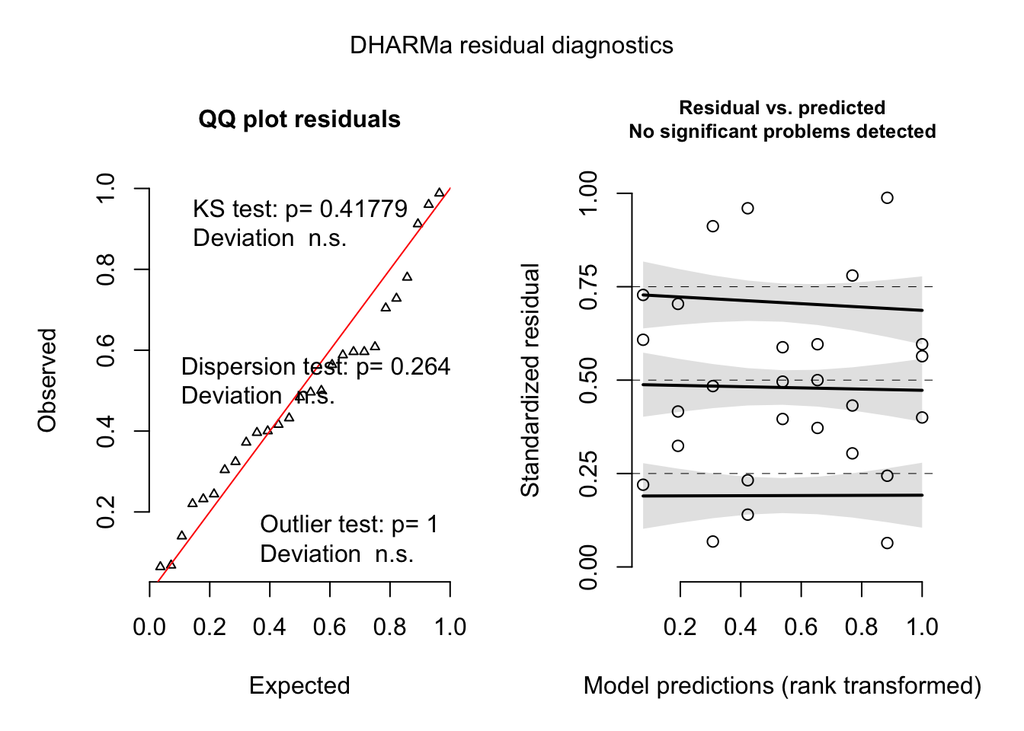

```
## Object of Class DHARMa with simulated residuals based on 250 simulations with refit = FALSE . See ?DHARMa::simulateResiduals for help.
##
## Scaled residual values: 0.96 0.14 0.232 0.416 0.704 0.324 0.064 0.988 0.244 0.068 0.484 0.912 0.22 0.608 0.728 0.596 0.564 0.4 0.596 0.372 ...
```

```r
# does data fit model?
simulateResiduals(FDiv, plot=T) # looks ok
```

```r
shapiro.test(residuals(FDiv)) # residuals are  normal
```

```
##
##  Shapiro-Wilk normality test
##
## data:  residuals(FDiv)
## W = 0.95752, p-value = 0.3241
```

```r
# significant pairs
FDiv_sig_pairs <-  as.data.frame(pairs(emmeans(FDiv, ~ climate * treatment)))%>%
  filter(p.value <= 0.05)

# all pairwise comparisons
emmeans(FDiv, pairwise ~ climate)
```

```
## NOTE: Results may be misleading due to involvement in interactions
```

```
## $emmeans
##  climate      emmean    SE  df asymp.LCL asymp.UCL
##  Arid          0.648 0.019 Inf     0.611     0.685
##  Intermediate  0.668 0.019 Inf     0.631     0.705
##  Mesic         0.731 0.019 Inf     0.694     0.769
##
## Results are averaged over the levels of: treatment
## Confidence level used: 0.95
##
## $contrasts
##  contrast             estimate     SE  df z.ratio p.value
##  Arid - Intermediate   -0.0202 0.0268 Inf -0.753  0.7321
##  Arid - Mesic          -0.0838 0.0268 Inf -3.126  0.0050
##  Intermediate - Mesic  -0.0636 0.0268 Inf -2.373  0.0464
##
## Results are averaged over the levels of: treatment
## P value adjustment: tukey method for comparing a family of 3 estimates
```

```r
emmeans(FDiv, pairwise ~ treatment)
```

```
## NOTE: Results may be misleading due to involvement in interactions
```

```
## $emmeans
##  treatment emmean    SE  df asymp.LCL asymp.UCL
##  Open       0.683 0.019 Inf     0.646     0.721
##  Partial    0.529 0.019 Inf     0.492     0.566
##  Total      0.834 0.019 Inf     0.797     0.871
##
## Results are averaged over the levels of: climate
## Confidence level used: 0.95
##
## $contrasts
##  contrast        estimate     SE  df z.ratio p.value
##  Open - Partial     0.154 0.0268 Inf   5.749 <.0001
##  Open - Total      -0.151 0.0268 Inf  -5.630 <.0001
##  Partial - Total   -0.305 0.0268 Inf -11.378 <.0001
##
## Results are averaged over the levels of: climate
## P value adjustment: tukey method for comparing a family of 3 estimates
```

```r
# emmeans(FDiv, pairwise ~ climate * treatment)
emmeans(FDiv, pairwise ~ climate | treatment)
```

```
## $emmeans
## treatment = Open:
##  climate      emmean     SE  df asymp.LCL asymp.UCL
##  Arid          0.661 0.0328 Inf     0.597     0.725
##  Intermediate  0.658 0.0328 Inf     0.594     0.723
##  Mesic         0.731 0.0328 Inf     0.666     0.795
##
## treatment = Partial:
##  climate      emmean     SE  df asymp.LCL asymp.UCL
##  Arid          0.464 0.0328 Inf     0.399     0.528
##  Intermediate  0.452 0.0328 Inf     0.388     0.517
##  Mesic         0.672 0.0328 Inf     0.608     0.736
##
## treatment = Total:
##  climate      emmean     SE  df asymp.LCL asymp.UCL
##  Arid          0.819 0.0328 Inf     0.754     0.883
##  Intermediate  0.893 0.0328 Inf     0.829     0.957
##  Mesic         0.791 0.0328 Inf     0.727     0.856
##
## Confidence level used: 0.95
##
## $contrasts
## treatment = Open:
##  contrast             estimate     SE  df z.ratio p.value
##  Arid - Intermediate   0.00251 0.0464 Inf  0.054  0.9984
##  Arid - Mesic         -0.06991 0.0464 Inf -1.506  0.2883
##  Intermediate - Mesic -0.07242 0.0464 Inf -1.560  0.2634
##
## treatment = Partial:
##  contrast             estimate     SE  df z.ratio p.value
##  Arid - Intermediate   0.01134 0.0464 Inf  0.244  0.9677
##  Arid - Mesic         -0.20857 0.0464 Inf -4.491  <.0001
##  Intermediate - Mesic -0.21991 0.0464 Inf -4.735  <.0001
##
## treatment = Total:
##  contrast             estimate     SE  df z.ratio p.value
##  Arid - Intermediate  -0.07438 0.0464 Inf -1.602  0.2449
##  Arid - Mesic          0.02708 0.0464 Inf  0.583  0.8292
##  Intermediate - Mesic  0.10146 0.0464 Inf  2.185  0.0738
##
## P value adjustment: tukey method for comparing a family of 3 estimates
```